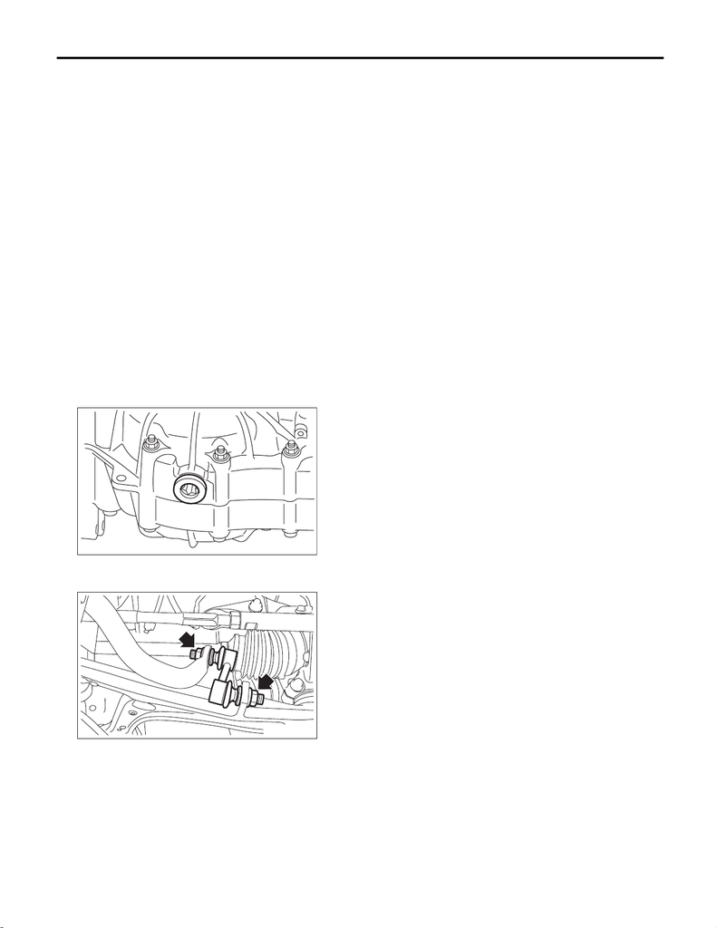

6MT(TY75)-42

Differential Side Retainer Oil Seal

MANUAL TRANSMISSION AND DIFFERENTIAL

6. Differential Side Retainer Oil Seal

A: INSPECTION

Check for transmission gear oil leaks at differential side retainer oil seal. If there is oil leakage, replace the

oil seal with the new part and check the drive shaft.

B: REPLACEMENT

1) Disconnect the ground cable from battery. <Ref. to NT-5, BATTERY, NOTE, Note.>

2) Lift up the vehicle.

3) Using the TORX

®

bit T70, remove the drain plug, and drain the transmission gear oil completely.

CAUTION:

• Immediately after the vehicle has been running or after idling for a long time, the transmission gear

oil will be hot. Be careful not to receive burns.

• Be careful not to spill the transmission gear oil on the exhaust pipe, to prevent emission of smoke

or causing a fire. If gear oil is spilled, wipe it off completely.

4) Tighten the drain plug using TORX

®

bit T70.

NOTE:

Use a new gasket.

Tightening torque:

44 N·m (4.5 kgf-m, 32.5 ft-lb) (aluminum gasket, silver)

70 N·m (7.1 kgf-m, 51.6 ft-lb) (copper gasket, brown)

70 N·m (7.1 kgf-m, 51.6 ft-lb) (metal gasket, black)

5) Remove the center exhaust pipe (rear). <Ref. to EX(w/o STI)-35, REMOVAL, Center Exhaust Pipe.>

6) Remove the stabilizer link.

MT-01548

MT-03070

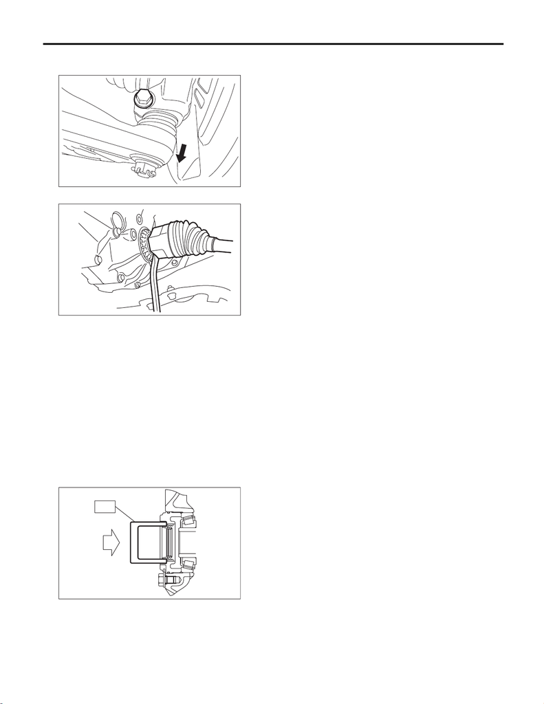

6MT(TY75)-43

Differential Side Retainer Oil Seal

MANUAL TRANSMISSION AND DIFFERENTIAL

7) Remove the bolt securing the ball joint of the front arm to the housing, then separate the front arms and

the housing.

8) Using a crowbar, separate the left and right front drive shafts.

9) Remove the differential side retainer oil seal.

NOTE:

• Be sure to replace the differential side retainer oil seal whenever the front drive shaft is removed from the

transmission.

• Use the ST 398527700 PULLER ASSY to remove the oil seal. If removing the oil seal with a flat tip screw-

driver, be careful not to scratch the differential side retainer.

10) Using the ST, install the differential side retainer oil seal by lightly tapping with a plastic hammer.

CAUTION:

• Apply transmission gear oil to the oil seal lips, and install the oil seal while being careful not to de-

form the lip.

• Check the identification marks (L, R) during installation not to mix up the oil seals RH and LH.

NOTE:

Use a new oil seal.

ST 18675AA000 DIFFERENTIAL SIDE OIL SEAL INSTALLER

MT-03073

MT-02593

ST

MT-00103

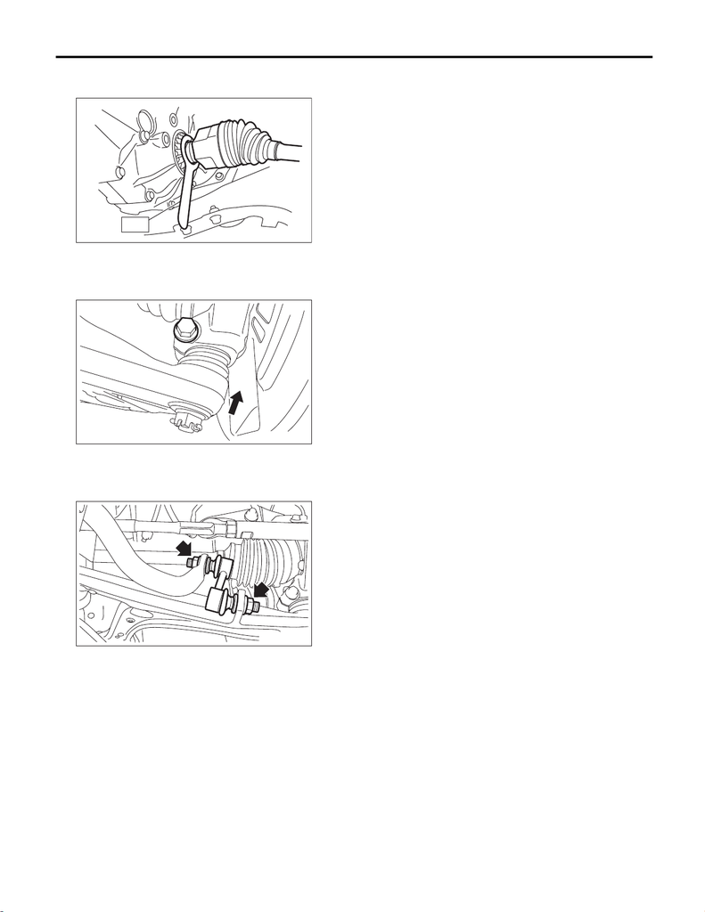

6MT(TY75)-44

Differential Side Retainer Oil Seal

MANUAL TRANSMISSION AND DIFFERENTIAL

11) Install the ST to the transmission, and then install the front drive shaft.

ST 28399SA010 OIL SEAL PROTECTOR

12) Insert the front arm ball joint and tighten the mounting bolt.

Tightening torque:

50 N·m (5.1 kgf-m, 36.9 ft-lb)

13) Install the stabilizer link.

Tightening torque:

60 N·m (6.1 kgf-m, 44.3 ft-lb)

14) Install the center exhaust pipe (rear). <Ref. to EX(w/o STI)-41, INSTALLATION, Center Exhaust Pipe.>

15) Lower the vehicle.

16) Pour in transmission gear oil and check the oil level. <Ref. to 6MT(TY75)-23, Transmission Gear Oil.>

17) Connect the battery ground terminal. <Ref. to NT-5, BATTERY, NOTE, Note.>

MT-02693

ST

MT-03093

MT-03070